# Reproducible Research/Peer-graded Assignment: Course Project1

yeonsuk, kim

2022-11-19

```r
knitr::opts_chunk$set(echo = TRUE)
library(readr)
library(reshape2)
library(stringr)
library(data.table)
library(lubridate)
library(sqldf)
library(dplyr)
```

```r
library(ggplot2)
library(knitr)

## global variables
working_dir <<- 'D:/WorkSpace/Github-R/05.Reproducible-Research'
relative_path <<- paste0(working_dir, '/Week2/RepData_PeerAssessment1/')
csv_filename <<- paste0(relative_path, 'activity.csv')

activity <- NULL
mutate_activity <- NULL
```

## A. Loading and preprocessing the data

```r
##--------------------
## read activity.csv file
## [activity.csv Format]
## - steps: Number of steps taking in a 5-minute interval (missing values are coded as NA)
## - date: The date on which the measurement was taken in YYYY-MM-DD format
## - interval: Identifier for the 5-minute interval in which measurement was taken
##--------------------
readActivity <- function() {
    ## check file.exists(), if "file does not exist" then
    if (!file.exists(csv_filename)) {
        print(paste0(csv_filename, ' does not exist! Please check exact filename.'))
    }

    ## read activity.csv file
    activity <- as.data.frame(fread(csv_filename))   # fread() is fast and efficient rather than read.csv().

    ## change type to Date
    activity$date <- as.Date(activity$date)

    ## structure
    # str(activity)
    # 'data.frame': 17568 obs. of  3 variables:
    # $ steps   : int  NA NA NA NA NA NA NA NA NA NA ...
    # $ date    : Date, format: "2012-10-01" "2012-10-01" "2012-10-01" "2012-10-01" ...
    # $ interval: int  0 5 10 15 20 25 30 35 40 45 ...

    ## change LOCALE to "English"
    Sys.setlocale("LC_TIME", "English")

    ## add the day of the week
    activity$wday1 <- wday(activity$date, label=TRUE)

    ## add new column with 'weekday' and 'weekend' values
    activity$wday <- 'weekday'

    ## update wday column value into "weekend", if (wday1=='Sat' | wday1=='Sun')
    activity[which(activity$wday1=='Sat' | activity$wday1=='Sun'), ]['wday'] <- 'weekend'

    ## change "wday" column type to factor
    activity$wday <- factor(activity$wday)

     ## count rows, if (wday1=='Sat' | wday1=='Sun')
    nrow(filter(activity, (wday1=='Sat' | wday1=='Sun')))   # 4608 rows

    table(activity$wday)
    # weekday weekend
    # 12960    4608

    ## structure
    str(activity)
    # 'data.frame': 17568 obs. of  5 variables:
    # $ steps   : int  NA NA NA NA NA NA NA NA NA NA ...
    # $ date    : Date, format: "2012-10-01" "2012-10-01" "2012-10-01" "2012-10-01" ...
    # $ interval: int  0 5 10 15 20 25 30 35 40 45 ...
    # $ wday1   : Ord.factor w/ 7 levels "Sun"<"Mon"<"Tue"<..: 2 2 2 2 2 2 2 2 2 2 ...
    # $ wday    : Factor w/ 2 levels "weekday","weekend": 1 1 1 1 1 1 1 1 1 1 ...

    ## dimension
    dim(activity)  # 17568, 4

    ## head()
    head(activity, 3)

    ## return to original LOCALE
    Sys.setlocale()

    summary(activity$steps)
    # Min. 1st Qu.  Median    Mean 3rd Qu.    Max.    NA's
    # 0.00    0.00    0.00   37.38   12.00  806.00    2304

    ## remove "wday1" column
    activity <- select(activity, c(1, 2, 3, 5))

    return(activity)
}


##--------------------
## A. Loading and preprocessing the data
## 2. read activity.csv file
##--------------------
activity <- readActivity()
```

```
## 'data.frame':    17568 obs. of  5 variables:
##  $ steps   : int  NA NA NA NA NA NA NA NA NA NA ...
##  $ date    : Date, format: "2012-10-01" "2012-10-01" ...
##  $ interval: int  0 5 10 15 20 25 30 35 40 45 ...
##  $ wday1   : Ord.factor w/ 7 levels "Sun"<"Mon"<"Tue"<..: 2 2 2 2 2 2 2 2 2 2 ...
##  $ wday    : Factor w/ 2 levels "weekday","weekend": 1 1 1 1 1 1 1 1 1 1 ...
```

## B. What is mean total number of steps taken per day?

#### 1. Calculate the total number of steps taken per day.

#### 2. Make a histogram of the total number of steps taken each day.

#### 3. Calculate and report the mean and median of the total number of steps taken per day.

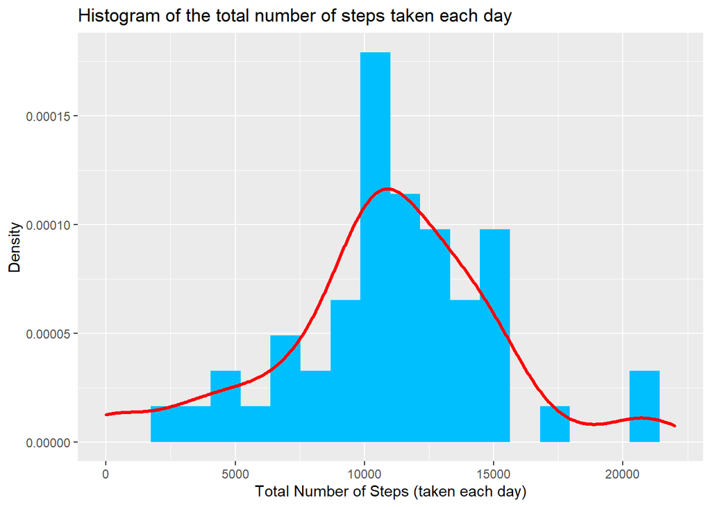

```
## [1] "Mean of the number of steps taken each day: 10766.19"
## [1] "Median of the number of steps taken each day: 10765"
```

```r
##--------------------
## Create Histogram()
##--------------------
createHistogram <- function(activity) {
    ## 1. group by each day, calculate the total number of steps taken per day.
    activity_groupby_date <- aggregate(steps ~ date, activity, sum)

    summary(activity_groupby_date$steps)
    # Min. 1st Qu.  Median    Mean 3rd Qu.    Max.
    # 41    8841   10765   10766   13294   21194

    ## 2. histogram of the total number of steps taken each day
    g <- ggplot(activity_groupby_date, aes(x=steps)) +
        geom_histogram(aes(y=..density..), bins=20, fill='deepskyblue', na.rm=TRUE) +
        geom_density(alpha = 0.2, na.rm = TRUE, color='red', lwd=1.2) +
        ggtitle('Histogram of the total number of steps taken each day') +
        scale_x_continuous(name='Total Number of Steps (taken each day)'
                           , limits=c(0, 22000)) +
        scale_y_continuous(name='Density')

    ## show the plot in the window
    print(g)

    ## 3. Mean and median number of steps taken each day
    ## Calculate mean
    print(paste0('Mean of the number of steps taken each day: '
                   , round(mean(activity_groupby_date$steps),2)))     # 10766.19

    ## Calculate median
    print(paste0('Median of the number of steps taken each day: '
                   , round(median(activity_groupby_date$steps),2)))   # 10765

}

##--------------------
## B. What is mean total number of steps taken per day?
## 3. Create a histogram
##--------------------
createHistogram(activity)
```

## C. What is the average daily activity pattern?

#### 1. Make a time series plot of the 5-minute interval (x-axis) and the average number of steps taken, averaged across all days (y-axis).

#### 2. Which 5-minute interval, on average across all the days in the dataset, contains the maximum number of steps?

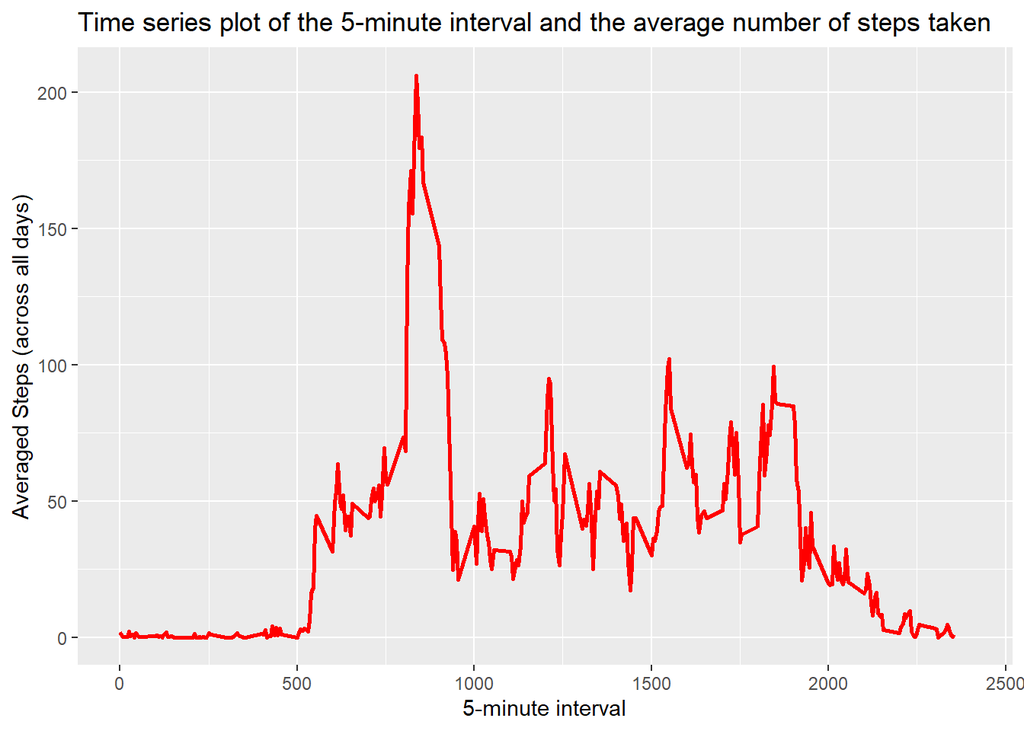

```
## [1] "Which 5-minute interval, contains the maximum number of steps? 835"
```

```r
##--------------------
## Create TimeSeries Plot()
## C. What is the average daily activity pattern?
##--------------------
createTimeSeriesPlot <- function(activity) {

    ## group by each day, get average number of steps taken
    activity_mean_timeseries <- aggregate(steps ~ interval, activity, mean)

    summary(activity_mean_timeseries$interval)
    # Min. 1st Qu.  Median    Mean 3rd Qu.    Max.
    # 0.0   588.8  1177.5  1177.5  1766.2  2355.0

    summary(activity_mean_timeseries$steps)
    # Min. 1st Qu.  Median    Mean 3rd Qu.    Max.
    # 0.000   2.486  34.113  37.383  52.835 206.170

    summary(activity$steps)
    # Min. 1st Qu.  Median    Mean 3rd Qu.    Max.    NA's
    # 0.00    0.00    0.00   37.38   12.00  806.00    2304

    ## Time Series Plot()
    g <- ggplot(activity_mean_timeseries, aes(x=interval, y=steps)) +
        ggtitle('Time series plot of the 5-minute interval and the average number of steps taken') +
        geom_line(color='red', lwd=1) +
        scale_x_continuous(name='5-minute interval'
                           , limits=c(0, 2400)) +
        scale_y_continuous(name='Averaged Steps (across all days)')

    print(g)

    ## c.2. Which 5-minute interval, on average across all the days in the dataset, contains the maximum number of steps?
    ## find index
    max_steps_idx <- activity_mean_timeseries$steps==max(activity_mean_timeseries$steps)

    print(paste0('Which 5-minute interval, contains the maximum number of steps? '
                   , activity_mean_timeseries[max_steps_idx, c('interval')]))          # 835

}


##--------------------
## C. What is the average daily activity pattern?
## 4. Create Time Series Plot
##--------------------
createTimeSeriesPlot(activity)
```

## D. Imputing missing values

#### 1. Calculate and report the total number of missing values in the dataset.

#### 2. Devise a strategy for filling in all of the missing values in the dataset.

#### The strategy does not need to be sophisticated.

#### For example, you could use the mean/median for that day, or the mean for that 5-minute interval, etc.

#### 3. Create a new dataset that is equal to the original dataset but with the missing data filled in.

#### 4. Make a histogram of the total number of steps taken each day and Calculate and report the mean and median total number of steps taken per day.

#### Do these values differ from the estimates from the first part of the assignment?

#### What is the impact of imputing missing data on the estimates of the total daily number of steps?

```
## [1] "The total number of missing values in the dataset (with NAs): 2304"
## [1] "[Compare median and mean]"
## [1] "Calculate median for 5-minute interval: the count (steps==0) is 235"
## [1] "Calculate mean for 5-minute interval: the count (steps==0) is 19"
## [1] "Thus, Use [mean] for imputing missing values!"
```

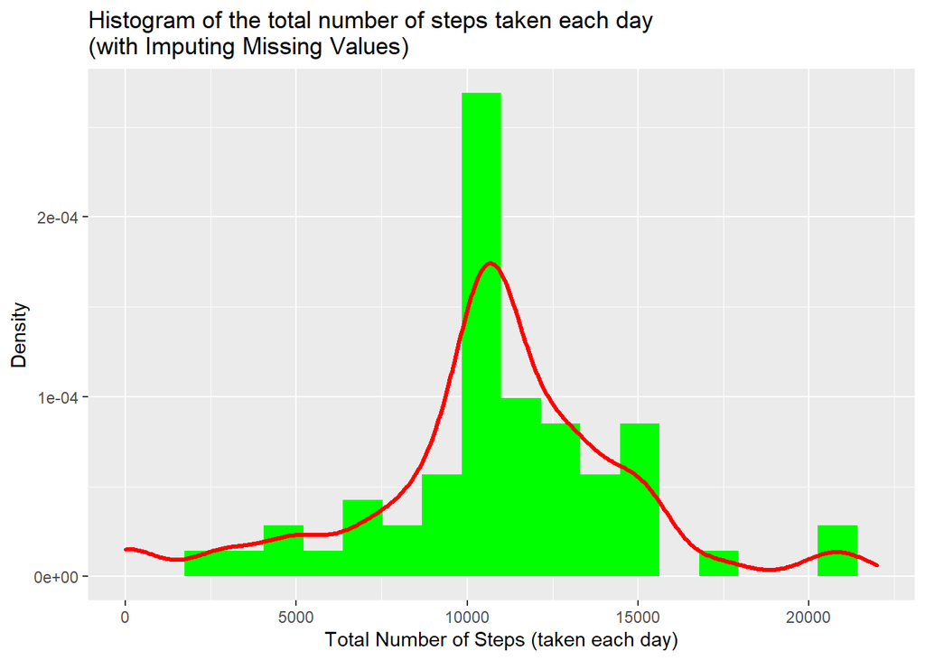

[output not shown]

```r
##--------------------
## D. Imputing missing values
##--------------------
imputeMissingValues <- function(activity) {

    ## D.1 check total number of missing values in the dataset.
    # summary(activity$steps, na.omit=TRUE)[[7]]
    print(paste0('The total number of missing values in the dataset (with NAs): '
                   , sum(is.na(activity$steps))))          # 2304

    ## D.2 Devise a strategy for filling in all of the missing values in the dataset.
    ## use median for that 5-minute interval for NAs.

    ## calculate median for 5-minute interval
    median_steps_byinterval <- aggregate(steps ~ interval, activity, median)

    print('[Compare median and mean]')
    print(paste0('Calculate median for 5-minute interval: the count (steps==0) is '
                 , sum(median_steps_byinterval$steps==0)  # 235
                 ))

    ## calculate mean for 5-minute interval  ==> use mean value
    mean_steps_byinterval <- aggregate(steps ~ interval, activity, mean)

    print(paste0('Calculate mean for 5-minute interval: the count (steps==0) is '
                 , sum(mean_steps_byinterval$steps==0)  # 19
                ))

    print(paste0('Thus, Use [mean] for imputing missing values!'))

    ## full_join()
    mutate_activity <- NULL
    mutate_activity <- full_join(activity, mean_steps_byinterval, by='interval')

    ## filter() data with NAs
    na_index_for_steps <- is.na(mutate_activity$steps.x)==TRUE

    ## mutate NAs into mean for 5-minute interval
    mutate_activity[na_index_for_steps, c('steps.x')] <- mutate_activity[na_index_for_steps, c('steps.y')]

    ## rename
    mutate_activity <- rename(mutate_activity, c('steps' = 'steps.x'))
    mutate_activity <- select(mutate_activity, -c('steps.y'))   # remove mean, steps.y column

    ## check NAs
    summary(mutate_activity$steps, na.omit=TRUE)
    # Min. 1st Qu.  Median    Mean 3rd Qu.    Max.
    # 0.00    0.00    0.00   37.38   27.00  806.00

    ## create Histogram with imputing missing values
    createHistogramWithImputingMissingValues(activity, mutate_activity)

    return(mutate_activity)
}


##--------------------
## D.4 Make a histogram of the total number of steps taken each day and Calculate and report the mean and median total number of steps taken per day.
##--------------------
createHistogramWithImputingMissingValues <- function(activity, mutate_activity) {

    ## data before imputing NAs
    activity_groupby_date <- aggregate(steps ~ date, activity, sum)
    summary(activity_groupby_date$steps)
    # Min. 1st Qu.  Median    Mean 3rd Qu.    Max.
    # 41    8841   10765   10766   13294   21194

    ## data after imputing NAs
    ## 1. group by each day, calculate the total number of steps taken per day. (imputing NAs)
    mutate_activity_groupby_date <- aggregate(steps ~ date, mutate_activity, sum)
    summary(mutate_activity_groupby_date$steps)
    # Min. 1st Qu.  Median    Mean 3rd Qu.    Max.
    # 41    9819   10766   10766   12811   21194

    ## 2. histogram of the total number of steps taken each day
    g <- ggplot(mutate_activity_groupby_date, aes(x=steps)) +
        geom_histogram(aes(y=..density..), bins=20, fill='green', na.rm=TRUE) +
        geom_density(alpha = 0.2, na.rm = TRUE, color='red', lwd=1.2) +
        ggtitle('Histogram of the total number of steps taken each day \n(with Imputing Missing Values)') +
        scale_x_continuous(name='Total Number of Steps (taken each day)'
                           , limits=c(0, 22000)) +
        scale_y_continuous(name='Density')

    ## show the plot in the window
    print(g)

    ## 4. Calculate and report the mean and median total number of steps taken per day.
    ## Calculate mean
    print('[Compare]')
    print(paste0('Mean of the number of steps taken each day (with NAs): '
                 , round(mean(activity_groupby_date$steps),2)
                ))
    print(paste0('Mean of the number of steps taken each day (with imputing missing values): '
                 , round(mean(mutate_activity_groupby_date$steps),2)
                 ))

    ## Calculate median
    print(paste0('Median of the number of steps taken each day (with NAs): '
                 , round(median(activity_groupby_date$steps),2)
                ))
    print(paste0('Median of the number of steps taken each day (with imputing missing values): '
                 , round(median(mutate_activity_groupby_date$steps),2)
                 ))

    print(paste0('[Conclusion] mean value was not changed. But, median value was changed after imputing missing values!!!'))
    print('Overall, the data distribution is almost unchanged.')

}


##--------------------
## D. Imputing missing values
## 5. Create Histogram with imputing missing values
##--------------------
mutate_activity <- imputeMissingValues(activity)  # mutate NAs
```

## E. Are there differences in activity patterns between weekdays and weekends?

```
## 'data.frame':    17568 obs. of  4 variables:
##  $ steps   : num  1.717 0.3396 0.1321 0.1509 0.0755 ...
##  $ date    : Date, format: "2012-10-01" "2012-10-01" ...
##  $ interval: int  0 5 10 15 20 25 30 35 40 45 ...
##  $ wday    : Factor w/ 2 levels "weekday","weekend": 1 1 1 1 1 1 1 1 1 1 ...
```

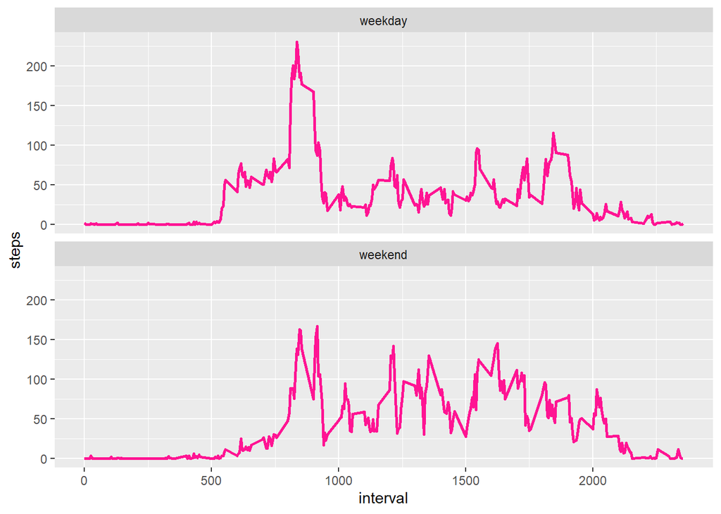

```
## [1] "[Conclusion]"
## [1] "On weekdays (steps), mean is 35.611, median is 25.803, and standard deviation is 41.619."
## [1] "On weekends (steps), mean is 42.366, median is 32.34, and standard deviation is 42.544."
## [1] "The mean, median, and standard deviation of weekend steps are slightly larger than weekdays."
```

```r
##--------------------
## E. Are there differences in activity patterns between weekdays and weekends?
## 6. Create Time Series Plot (weekday days or weekend days)
##--------------------
createTimeSeriesPlotForWeekdaysWeekends <- function(mutate_activity) {

    ## structure of mutate_activity (dataset with mutating missing values)
    str(mutate_activity)
    # 'data.frame': 17568 obs. of  4 variables:
    # $ steps   : num  1.717 0.3396 0.1321 0.1509 0.0755 ...
    # $ date    : Date, format: "2012-10-01" "2012-10-01" "2012-10-01" "2012-10-01" ...
    # $ interval: int  0 5 10 15 20 25 30 35 40 45 ...
    # $ wday    : Factor w/ 2 levels "weekday","weekend": 1 1 1 1 1 1 1 1 1 1 ...

    head(mutate_activity, 3)
    # steps       date interval    wday
    # 1 1.7169811 2012-10-01        0 weekday
    # 2 0.3396226 2012-10-01        5 weekday
    # 3 0.1320755 2012-10-01       10 weekday

    ## group by each day, get average number of steps taken
    mutate_activity_mean_timeseries <- aggregate(steps ~ interval + wday, mutate_activity, mean)

    summary(mutate_activity_mean_timeseries$interval)
    # Min. 1st Qu.  Median    Mean 3rd Qu.    Max.
    # 0.0   588.8  1177.5  1177.5  1766.2  2355.0

    ## Time Series Plot()
    g <- ggplot(mutate_activity_mean_timeseries, aes(x=interval, y=steps)) +
        geom_line(color='deeppink', lwd=1) +
        facet_wrap(. ~ wday, nrow=2, ncol=1)
        ggtitle('Time series plot of the 5-minute interval and the average number of steps taken \n(between weekdays and weekends)') +
        scale_x_continuous(name='5-minute interval'
                           , limits=c(0, 2400)) +
        scale_y_continuous(name='Average number of steps taken (across all days)')

    print(g)

    ## [Compare between weekday and weekend]
    ## descriptive statistics of steps for "weekday"
    weekday_index <- mutate_activity_mean_timeseries$wday=='weekday'
    summary(mutate_activity_mean_timeseries[weekday_index, c('steps')])
    # Min. 1st Qu.  Median    Mean 3rd Qu.    Max.
    # 0.000   2.247  25.803  35.611  50.854 230.378

    ## standard deviation for "weekday"
    sd(mutate_activity_mean_timeseries[weekday_index, c('steps')])
    # 41.61918

    ## descriptive statistics of steps for "weekend"
    weekend_index <- mutate_activity_mean_timeseries$wday=='weekend'
    summary(mutate_activity_mean_timeseries[weekend_index, c('steps')])
    # Min. 1st Qu.  Median    Mean 3rd Qu.    Max.
    # 0.000   1.241  32.340  42.366  74.654 166.639

    ## standard deviation for "weekend"
    sd(mutate_activity_mean_timeseries[weekend_index, c('steps')])
    # 42.5439

    print('[Conclusion]')
    print(paste0('On weekdays (steps), mean is '
                 , round(mean(mutate_activity_mean_timeseries[weekday_index, c('steps')]), 3)
                 , ', median is '
                 , round(median(mutate_activity_mean_timeseries[weekday_index, c('steps')]), 3)
                 , ', and standard deviation is '
                 , round(sd(mutate_activity_mean_timeseries[weekday_index, c('steps')]), 3)
                 , '.'
                 ))

    print(paste0('On weekends (steps), mean is '
                 , round(mean(mutate_activity_mean_timeseries[weekend_index, c('steps')]), 3)
                 , ', median is '
                 , round(median(mutate_activity_mean_timeseries[weekend_index, c('steps')]), 3)
                 , ', and standard deviation is '
                 , round(sd(mutate_activity_mean_timeseries[weekend_index, c('steps')]), 3)
                 , '.'
    ))

    print('The mean, median, and standard deviation of weekend steps are slightly larger than weekdays.')

}


##--------------------
## E. Are there differences in activity patterns between weekdays and weekends?
## 6. Create Time Series Plot (weekday days or weekend days)
##--------------------
createTimeSeriesPlotForWeekdaysWeekends(mutate_activity)
```